# Projet d’analyse de données

Contrôle Continu

Auteur·rice

Robin M. - Rouabah Y. - Bonnin M.

Date de publication

5 novembre 2025

# Projet d’analyse de données

**Présentation et exploration des datas**

Les données proviennent d’un **ficher .csv**. Le fichier contient **10 847** lignes pour **40 colonnes**, soit **433 880** données.

Ce sont des données mesurées sur des joueurs de foot provenant de différents GPS.

### Identification de mes variables

- **dataset_version** : Je pense que c’est simplement la version du jeu de donnée (Qualitative Unique)
- **session_id** : Cela doit être l’identifiant de la session (Quantitative Discrète)
- **date** : Date de la session (Qualitative Ordinale)
- **start_time_local** : Heure locale du début de la session (Qualitative Ordinale)
- **athlete_id** : Identifiant de l’athlète (Quantitative Discrète)
- **team** : Équipe (Qualitative Nominale)
- **coach** : Nom du coach de la session (Qualitative Nominale)
- **gender** : Sexe de l’athlète (Qualitative Nominale)
- **position** : Poste de l’athlète (Qualitative Nominale)
- **dominant_foot** : Pied dominant (Qualitative Nominale)
- **dob** : Date de naissance (Quantitative Discrète)
- **height_cm** : Taille de l’athlète (Quantitative Continue)
- **body_mass_kg** : Masse corporelle de l’athlète (Quantitative Continue)
- **vo2max_ml_kg_min** : VO2max relative (Quantitative Continue)
- **availability** : Disponibilité à l’entraînement (Qualitative Nominale)
- **session_type** : Type de session (Qualitative Nominale)
- **surface** : Type de surface (Qualitative Nominale)
- **surface_risk_level** : Indice de risque lié à la surface (Qualitative Nominale)
- **device_type** : Identifiants des GPS (Qualitative Nominale)
- **weather** : Conditions météo (Qualitative Nominale)
- **temperature_c** : Température ambiante (Quantitative Continue)
- **duration_min** : Durée totale de la session (Quantitative Continue)
- **rpe** : Rate of Perceived Exertion (Qualitative Ordinale)
- **srpe** : Session rpe = rpe durée (min) (Quantitative Discrète)
- **heart_rate_avg** : Fréquence cardiaque moyenne (Quantitative Continue)
- **heart_rate_max** : Fréquence cardiaque maximale (Quantitative Continue)
- **distance_km** : Distance totale parcourue (Quantitative Continue)
- **high_speed_km** : Distance parcourue à haute vitesse (Quantitative Continue)
- **accelerations** : Nombre d’accélérations (Quantitative Discrète)
- **decelerations** : Nombre de décélérations (Quantitative Discrète)
- **avg_power_w** : Puissance moyenne (Quantitative Continue)
- **blood_latate_mmol** : Lactate sanguin (mmol/L) (Quantitative Continue)
- **session_load_zscore** : Z-score de charge (Normalisation) (Quantitative Continue)
- **env_condition_index** : Indice composite des conditions environnementales (Quantitative Continue)
- **sleep_hours_prev_night** : Heures de sommeil la nuit précédente (Quantitative Discrète)
- **mood_1to5** : Humeur du jour (de 1 à 5) (Qualitative Ordinale)
- **soreness_1to5** : Douleurs musculaires (de 1 à 5) (Qualitative Ordinale)
- **wellness_label** : Catégorie de bien-être globale (Qualitative Nominale)
- **injury_risk_score** : Score de risque de blessure (Quantitative Continue)
- **injury_status** : Statut actuel de blessure (Qualitative Nominale)

Tableau n°1 : Statistiques descriptives de mes variables

|  | dataset_version | session_id | date | start_time_local | athlete_id | team | coach | gender | position | dominant_foot | dob | height_cm | session_type | surface | surface_risk_level | device_type | weather | temperature_c | duration_min | rpe | srpe | heart_rate_avg | heart_rate_max | distance_km | high_speed_m | accelerations | decelerations | avg_power_w | blood_lactate_mmol | … |
| --- | --- | --- | --- | --- | --- | --- | --- | --- | --- | --- | --- | --- | --- | --- | --- | --- | --- | --- | --- | --- | --- | --- | --- | --- | --- | --- | --- | --- | --- | --- |
|  | Min. :2 | Length:10847 | Length:10847 | Length:10847 | Length:10847 | Length:10847 | Length:10847 | Length:10847 | Length:10847 | Length:10847 | Min. :1997-02-25 | Min. :149.0 | Length:10847 | Length:10847 | Length:10847 | Length:10847 | Length:10847 | Min. :-2.00 | Min. : 30.00 | Min. :1.000 | Min. : 30.0 | Min. :104.0 | Min. :129.0 | Min. : 1.230 | Min. : 28.0 | Min. : 5.00 | Min. : 5.00 | Min. :150.0 | Min. :0.800 | … |
|  | 1st Qu.:2 | Class :character | Class :character | Class :character | Class :character | Class :character | Class :character | Class :character | Class :character | Class :character | 1st Qu.:1999-02-27 | 1st Qu.:165.3 | Class :character | Class :character | Class :character | Class :character | Class :character | 1st Qu.:16.10 | 1st Qu.: 58.90 | 1st Qu.:4.000 | 1st Qu.:257.6 | 1st Qu.:143.0 | 1st Qu.:177.0 | 1st Qu.: 4.550 | 1st Qu.: 246.0 | 1st Qu.:19.00 | 1st Qu.:17.00 | 1st Qu.:262.9 | 1st Qu.:4.000 | … |
|  | Median :2 | Mode :character | Mode :character | Mode :character | Mode :character | Mode :character | Mode :character | Mode :character | Mode :character | Mode :character | Median :2001-04-25 | Median :171.2 | Mode :character | Mode :character | Mode :character | Mode :character | Mode :character | Median :19.70 | Median : 70.00 | Median :5.000 | Median :341.5 | Median :151.0 | Median :186.0 | Median : 6.350 | Median : 517.5 | Median :23.00 | Median :21.00 | Median :300.2 | Median :4.900 | … |
|  | Mean :2 | NA | NA | NA | NA | NA | NA | NA | NA | NA | Mean :2001-06-02 | Mean :171.3 | NA | NA | NA | NA | NA | Mean :19.55 | Mean : 70.54 | Mean :4.899 | Mean :351.4 | Mean :151.2 | Mean :185.7 | Mean : 6.686 | Mean : 562.9 | Mean :23.78 | Mean :21.59 | Mean :299.9 | Mean :4.879 | … |
|  | 3rd Qu.:2 | NA | NA | NA | NA | NA | NA | NA | NA | NA | 3rd Qu.:2003-08-20 | 3rd Qu.:177.2 | NA | NA | NA | NA | NA | 3rd Qu.:22.20 | 3rd Qu.: 81.80 | 3rd Qu.:6.000 | 3rd Qu.:432.4 | 3rd Qu.:159.0 | 3rd Qu.:195.0 | 3rd Qu.: 8.430 | 3rd Qu.: 820.8 | 3rd Qu.:28.00 | 3rd Qu.:26.00 | 3rd Qu.:337.4 | 3rd Qu.:5.700 | … |
|  | Max. :2 | NA | NA | NA | NA | NA | NA | NA | NA | NA | Max. :2005-12-27 | Max. :197.0 | NA | NA | NA | NA | NA | Max. :38.00 | Max. :135.90 | Max. :9.000 | Max. :946.8 | Max. :229.0 | Max. :210.0 | Max. :38.040 | Max. :1907.0 | Max. :56.00 | Max. :53.00 | Max. :505.6 | Max. :9.600 | … |
|  | NA | NA | NA | NA | NA | NA | NA | NA | NA | NA | NA | NA | NA | NA | NA | NA | NA | NA | NA | NA | NA | NA's :854 | NA's :876 | NA's :677 | NA's :553 | NA's :332 | NA's :302 | NA's :4858 | NA's :4303 | … |

Après une première observation des données, on remarque que les colonnes “**heart_rate_avg**”, “**heart_rate_max**”, “**distance_km**”, “**high_speed_m**”, “**accelerations**”, “**decelerations**”, “**avg_power_w**” et “**blood_lactate_mmol**” contiennent beaucoup de valeurs manquantes.

Tableau n°2 : Statistiques descriptives de la fréquence cardiaque moyenne

| Statistique | Valeur |
| --- | --- |
| Nombre | 10847.00 |
| Minimum | 104.00 |
| Quartiles_1 | 143.00 |
| Médiane | 151.00 |
| Moyenne | 151.18 |
| Quartiles_3 | 159.00 |
| Maximum | 229.00 |
| Mode | NA |
| Étendue | 125.00 |
| Écart_type | 12.73 |
| Variance | 162.16 |
| Coeff_Variance | 8.42 |
| Écart_Interquartile | 16.00 |

J’avais créé une fonction pour mon mémoire de l’année dernière qui me permettait de faire une analyse un peu plus poussée. Voici un exemple sur la variable fréquence cardiaque moyenne qui, nous le verrons, contient pas mal de valeurs aberrantes. (*Tableau n°2*).

Tableau n°3 : Statistiques descriptives de mes variables principales

| Titre | Athlètes | Hommes | Femmes | Attaquants | Defenseurs | Milieux | Goals | Pied Droit | Pied Gauche | Ambidextre | Team A | Team B | Team C | Team D | Vitesse | Récupération | Endurance | Technique | Force | Match | Âge | Poids | Taille | VO2max |
| --- | --- | --- | --- | --- | --- | --- | --- | --- | --- | --- | --- | --- | --- | --- | --- | --- | --- | --- | --- | --- | --- | --- | --- | --- |
| Totaux | 10847 | 5571.00 | 5276.00 | 2503.000 | 3675.00 | 3587.000 | 1082.000 | 8607.000 | 1792.000 | 448.00 | 2814.000 | 2675.000 | 2540.000 | 2818.00 | 2215.00 | 1057.000 | 2698.000 | 2137.000 | 1664.000 | 1076.00 | 23.988 | 68.013 | 171.254 | 48.705 |
| Proportions | 10847 | 51.36 | 48.64 | 23.076 | 33.88 | 33.069 | 9.975 | 79.349 | 16.521 | 4.13 | 25.943 | 24.661 | 23.417 | 25.98 | 20.42 | 9.745 | 24.873 | 19.701 | 15.341 | 9.92 | NA | NA | NA | NA |

On a fait un tableau de statistiques descriptives assez simple afin de créer nos graphiques à suivre (*Tableau n°3*).

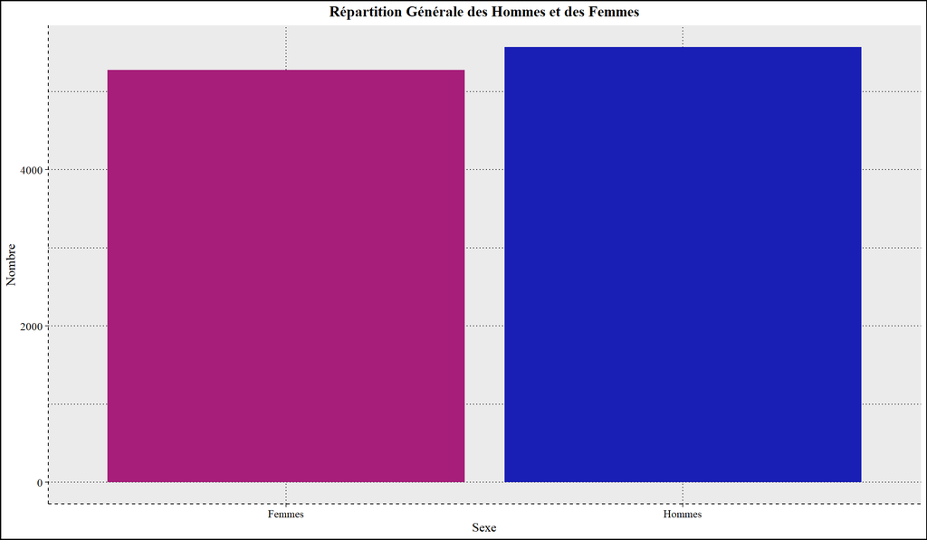

Graphique n°1 : Répartition générale du sexe

On remarque une répartition équivalente des hommes et des femmes, on a **51.36 %** d’hommes pour **48.64 %** de femmes (*Graphique n°1*).

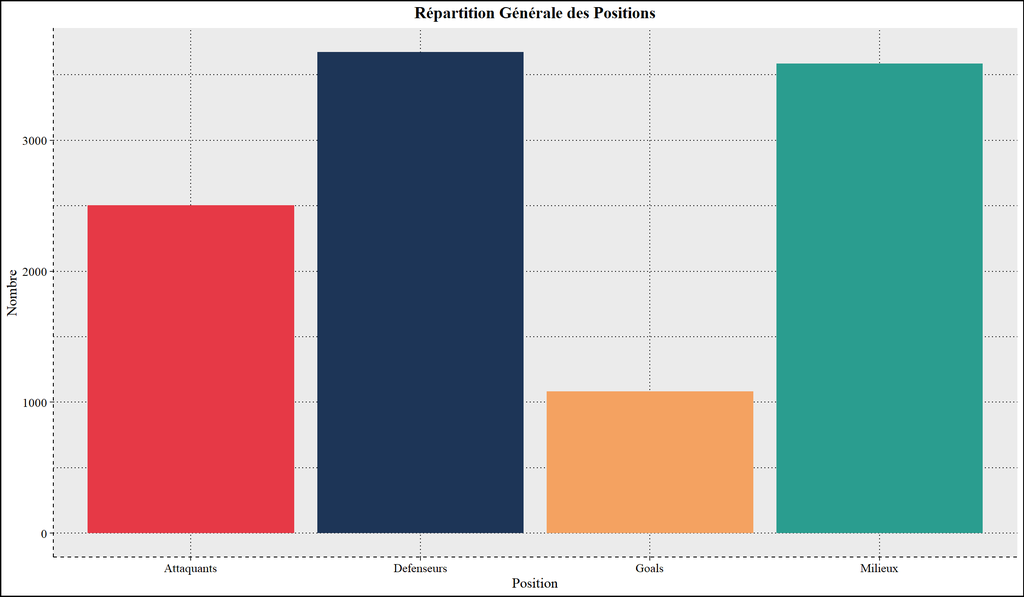

Graphique n°2 : Répartition des positions

On observe une répartition très hétérogène des différentes positions. On a **23.08 %** d’attaquants, **33.88 %** de défenseurs, **33.07 %** de milieux et **9.98 %** de goals (*Graphique n°2*).

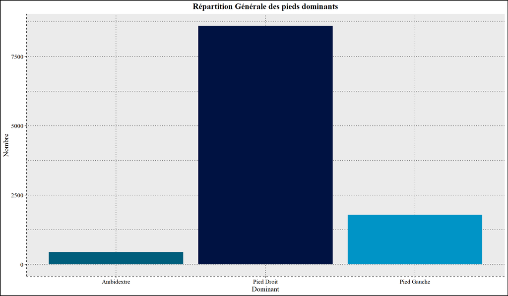

Graphique n°3 : Répartition des Pieds Dominants

On observe une répartition très hétérogène des pieds dominants. On a **79.35% %** de pieds droits, **16.52 %** de pieds gauches et **4.13 %** d’ambidextre (*Graphique n°3*).

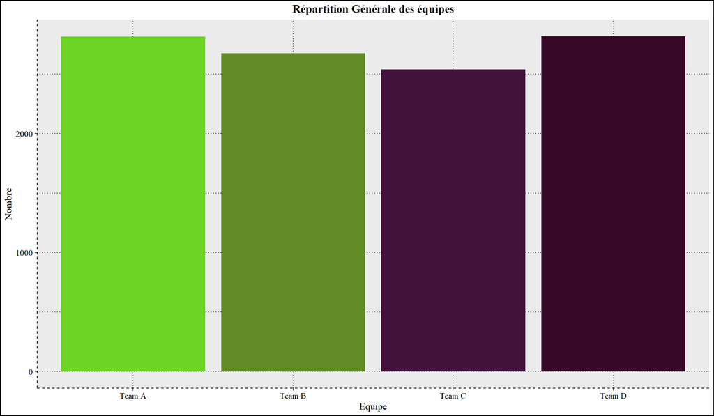

Graphique n°4 : Répartition des équipes

On observe une répartition très homogène des athlètes au sein des différentes équipes. On a **25.94 %** d’athlètes dans l’équipe A, **24.66 %** d’athlètes dans l’équipe B, **23.42 %** d’athlètes dans l’équipe C et **25.98 %** d’athlètes dans l’équipe D (*Graphique n°4*).

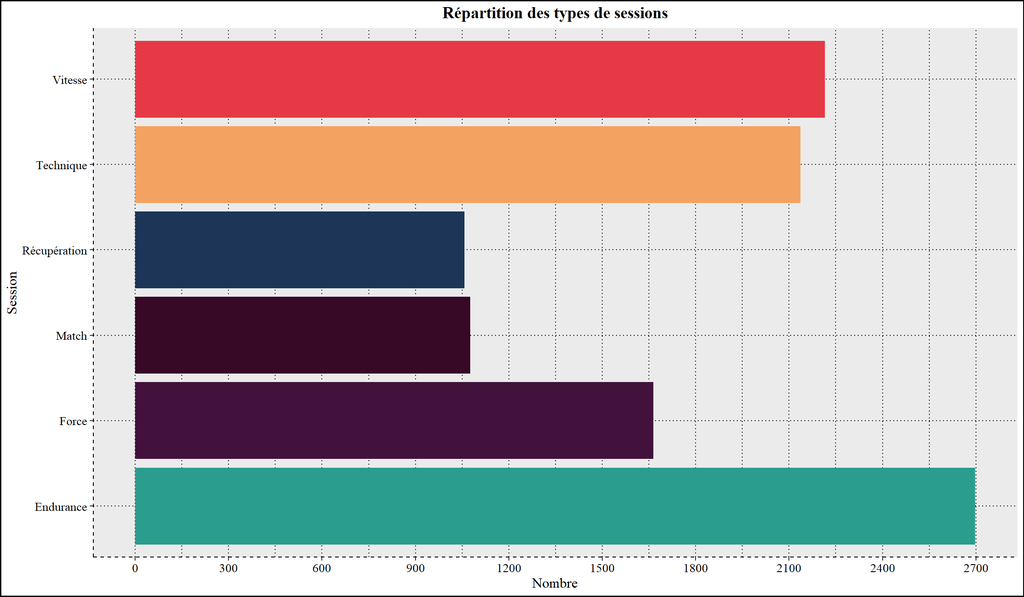

Graphique n°5 : Répartition des types de sessions

On observe une répartition hétérogène des différents types de session. On a **20.42 %** De séances de vitesse, **9.74 %** de séances de récupération, **24.87 %** de séance d’endurance, **19.70 %** de séance technique, **15.34 %** de séance de force et **9.92 %** de matchs (*Graphique n°5*).

**Nettoyage et préparation**

Après observation des données on remarque en effet certaines **valeurs aberrantes** au sein de certaines variables.

On peut noter qu’au sein de la variable **heart_rate_avg** il existe des valeurs **extrêmement hautes**, complètement hors d’une plage logique, une fréquence cardiaque moyenne sur une séance au-dessus de 200, c’est déjà très rare, voire déjà impossible alors à 229, ce n’est pas possible (*Graphique n°6*). Je décide de remplacer par des NA’s toutes les fréquence cardiaques moyennes supérieures à 190 par mesure de sécurité.

J’ai aussi remarqué que la fréquence cardiaque max est bloquée à 210 bpm. Sans avoir de source scientifique sous la main pour étayer mon propos, je pense que le GPS est très mauvais pour mesurer la FCmoy et la FCmax.

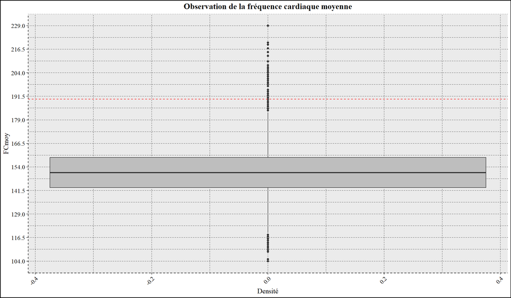

Graphique n°6 : Observation de la fréquence cardiaque moyenne

On remarque des valeurs aberrantes dans la variable distance_km (*Graphique n°7*). Plus de 20 km par séance, je pense que c’est beaucoup, alors 38 km, en 1h40 de séance, c’est impossible. J’ai créé une variable que j’ai appelé **session_km_h** afin de voir les vitesses moyennes aberrantes.

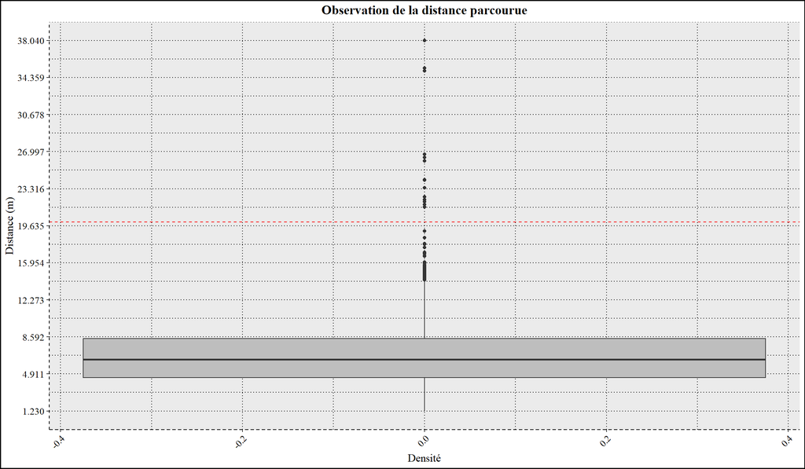

Graphique n°7 : Observation de la distance parcourue

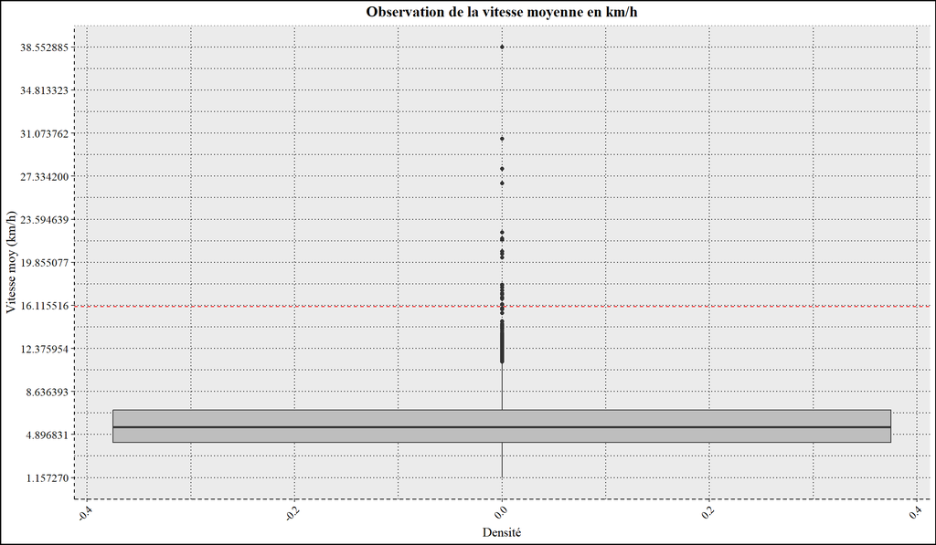

Graphique n°8 : Observation de la vitesse moyenne en km/h

On peut voir en effet des vitesses moyennes au dessus de 16 km/h jusqu’à 38 km/h (*Graphique n°8*). Je décide de remplacer toutes les distances pour lesquelles la vitesse moyenne est supérieure à 16 km/h par des NA’s.

Je remarque aussi des variables aberrantes au sein de la variable **session_load_zscore** (*Graphique n°9*). Certains zscores montent jusqu’à 4, au dessus de 3 c’est déjà un outlier. Je décide de remplacer par des NA’s toutes les valeurs au-dessus de 3.

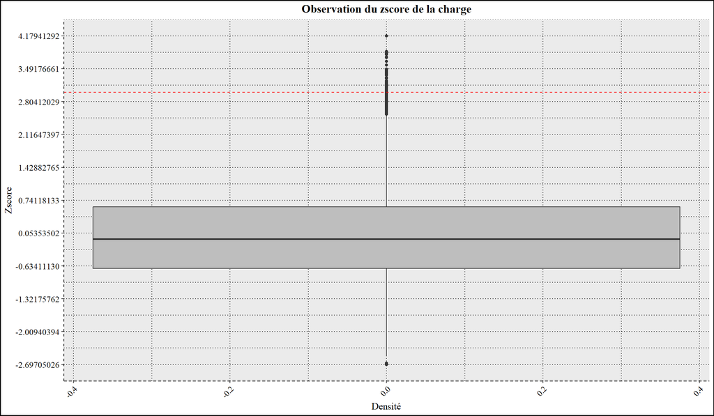

Graphique n°9 : Observation du zscore de la charge

### Mes nouvelles variables

- **age** : J’ai calculé une variable pour l’âge des joueurs (année) = `floor(as.numeric(interval(dob, today()) / years(1)))`. J’ai utilisé cette variable pour faire des statistiques dans le premier tableau.
- **session_km_h** : J’ai calculé une variable de déplacement moyen sur la séance (km/h) = `distance_km / (duration_min / 60)`. J’ai utilisé cette variable pour déterminer les valeurs aberrantes de la colonne distance.
- **sleep_category** : J’ai créé une nouvelle variable de catégorie de sommeil afin de faciliter la représentation et les calculs = `cut(sleep_hours_prev_night, breaks = c(-Inf, 6, 7, 8.5, Inf), labels = c("Très court", "Court", "Normal", "Long"))`
- **load_external_ration** : J’ai calculé une variable d’intensité de déplacement (km/min) = `distance_km / duration_min`
- **accel_density** : J’ai calculé une variable du nombre d’accélérations et de décélérations par km (nombre de changement de directions / km) = `(accelerations + decelerations) / distance_km`
- **neuromuscular_stress** : J’ai calculé une variable de Nombre de changements de directions par minutes = `(accelerations + decelerations) / duration_min`
- **power_density** : J’ai calculé une variable de Puissance relative = `avg_power_w / body_mass_kg`
- **power_per_distance** : J’ai calculé une variable de Puissance moyenne par unité de distance = `avg_power_w / distance_km`
- **training_impulse** : J’ai calculé une variable d’Estimation de la charge interne globale = `(duration_min * heart_rate_avg) / 100`
- **distance_per_vo2** : J’ai calculé une variable de VO2max par unité de distance = `distance_km / vo2max_ml_kg_min`
- **heart_rate_reserve_ratio** : J’ai calculé une variable de Pourcentage de la réserve cardiaque utilisée = `heart_rate_avg / heart_rate_max`. Que j’ai utilisé pour un nouveau nettoyage.
- **srpe_per_kg** : J’ai calculé une variable de Charge relative à la masse corporelle = `srpe / body_mass_kg`
- **readiness_score** : J’ai calculé une variable d’État de l’athlète à encaisser une charge = `sleep_hours_prev_night * (mood_1to5 / soreness_1to5)`
- **recovery_ratio** : J’ai calculé une variable de Rapport entre la charge interne et le sommeil = `sleep_hours_prev_night / srpe`
- **efficiency_ratio** : J’ai calculé une variable d’Efficacité énergétique = `distance_km / srpe`
- **heart_rate_efficiency** : J’ai calculé une variable de Distance par bpm moyen = `distance_km / heart_rate_avg`

Après une seconde observation des données j’ai effectué un second nettoyage. J’ai remplacé par des NA’s toutes les fréquences cardiaques de réserve supérieures à 100%. Ce qui veut dire que la fréquence cardiaque moyenne est supérieure à la fréquence cardiaque maximale, ce qui est impossible. J’ai remplacé aussi par des NA’s les fréquences cardiaques moyennes correspondantes.

**Analyse descriptive bi-variée**

### Problématique n°1

Afin de ne pas traiter **toutes** les problématiques **possibles** et **imaginables** sur nos datas, nous avons décidé d’en identifier *quelques-unes* de *pertinentes* et d’y répondre *correctement*. On a 40 variables, plus de 50 après le calcul des nouvelles variables, donc possiblement 1 225 liaisons observables, voire beaucoup plus si on prend en comptes les groupes des variables catégorielles. Complètement impossible de vérifier toutes les hypothèses imaginables.

Ainsi,

Nous avons identifié une première problématique qui pourrait être : **Est-ce que le type de session influence la charge interne ?**

#### Observation graphique

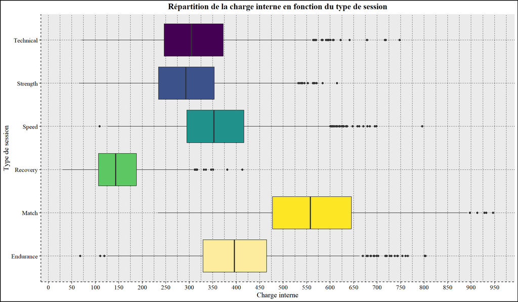

Graphique n°10 : Répartition de la charge interne en fonction du type de session

Dans ce premier graphique de relation entre notre charge interne et le type de session, on remarque une charge interne plus marquée pour certains types de sessions, et à l’inverse moins marquée pour d’autre. On peut faire l’hypothèse que **le type de session influence la charge interne** (*Graphique n°10*). On peut même faire une hypothèse plus précise en accord avec notre graphique, qui est que **le type de session Match influence positivement la charge interne**. c’est-à-dire que le type de session Match aurait tendance à augmenter la charge interne par rapport aux autres types de sessions.

En **H0** : on a la charge interne dépend du type de session.

En **H1** : on a la charge interne ne dépend pas du type de session.

Nous allons tenter de vérifier notre hypothèse à l’aide d’une **ANOVA à un facteur** avec le type de session comme variable explicative. Nous allons vérifier la **normalité** de nos données et l’**homogénéité des variances** afin de faire le choix le plus robuste quant à notre test statistique.

Si le test s’avère concluant et qu’il existe en effet une différence significative dans au moins l’un des groupes, nous feront un test **Post-Hoc** afin de déterminer le ou les groupes différents significatifs.

Nous allons ensuite effectuer un test de taille et de direction d’effet afin de déterminer l’ampleur et la direction de la différence entre les groupes potentiellement différents.

### Problématique n°2

Nous avons identifié une deuxième problématique : **Est-ce que les types de blessures dépendent de la position ?**

Nous trouvons cette problématique très intéressante, et nous faisons l’hypothèse, qu’**il existe un lien entre la position et le type de blessure.**

**H0** : Le type de blessure dépend de la position.

**H1** : Le type de blessure ne dépend pas de la position.

Pour vérifier cette hypothèse nous allons effectuer un test du Chi² sur variables catégorielles. Nous allons pouvoir déterminer s’il existe, ou non, une association significative entre ces deux variables.

#### Observation graphique

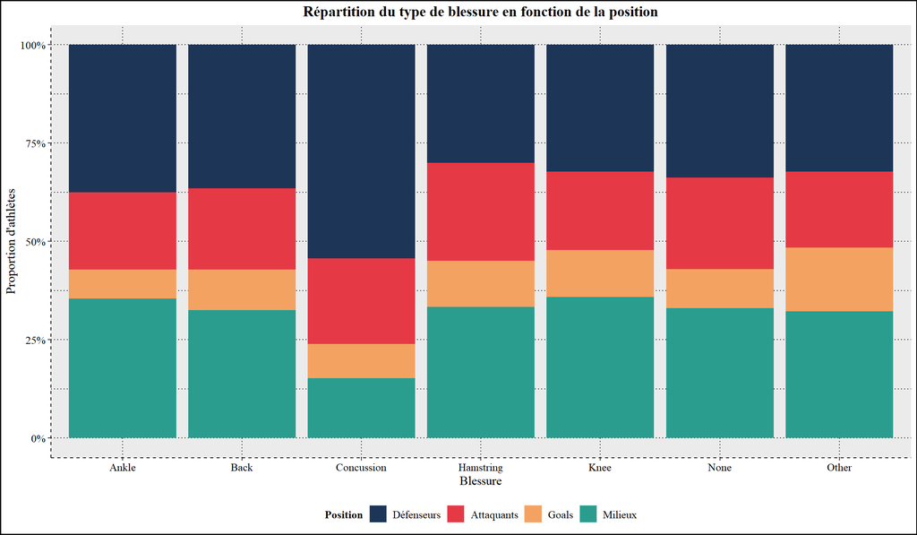

Graphique n°11 : Répartition du type de blessure en fonction de la position

Dans ce graphique on observe une différence potentielle chez les défenseurs. On peut faire l’hypothèse plus ciblée que **les défenseurs développeraient plus de commotions** (*Graphique n°11*). On n’observe pas de différence sur les autres blessures en fonction de la position sur ce graphique.

### Problématique n°3

Nous avons dégagé une troisième problématique un peu plus large : **De quoi dépend le risque de blessure ?**

**H0** : Le risque de blessure dépend d’au moins une variable

**H1** : Le risque de blessure ne dépend d’aucune variable

Pour vérifier cette hypothèse, nous allons devoir choisir des tests différenciés selon le type de variable.

On va commencer par faire un t-test sur deux échantillons indépendants afin d’observer une association ou non entre le genre et le risque de blessure, mais dans ce cas précis, c’est uniquement dans l’objectif de déterminer s’il existe un lien entre ces deux variables sans prendre en compte les autres.

Dans un premier temps, on va vérifier la normalité de notre variable injury_risk_score et l’homogénéité des variances entre notre variable quantitative continue et nos variables catégorielles.

Ensuite, nous allons faire des ANOVA à un facteur entre le risque de blessure et nos variables catégorielles. Nous avons choisi d’étudier les variables : **gender** ; **position** ; **session_type** ; **surface** ; **sleep_category**. Nous avons choisi de ne pas étudier les autres variables catégorielles pour des raisons de simplification et d’importance.

Le but de ces premiers tests est de déterminer le lien, séparément de chaque variables catégorielles avec le risque de blessure.

Pour aller plus loin, on va faire un modèle linéaire généralisé (Generalized Linear Model [GLM]) afin d’étudier l’interaction de nos variables catégorielles avec le risque de blessure. Par exemple, est-ce qu’être une femme en défense augmente le risque de blessure ?

D’autre part, nous allons effectuer une matrice de corrélation entre le risque de blessure et nos variables quantitatives continues d’intérêt. Nous allons tester les variables : **srpe** ; **distance_km** ; **high_speed_km** ; **accelerations** ; **deccelerations**. On va tester la normalité de nos variables avant d’effectuer tous tests de corrélations.

Pour terminer, on va produire un modèle de régression linéaire multiple entre le risque de blessure et nos variables quantitatives d’intérêts afin de déterminer les interactions de ces variables, dépendantes les unes des autres, avec le risque de blessure.

#### Observation graphique

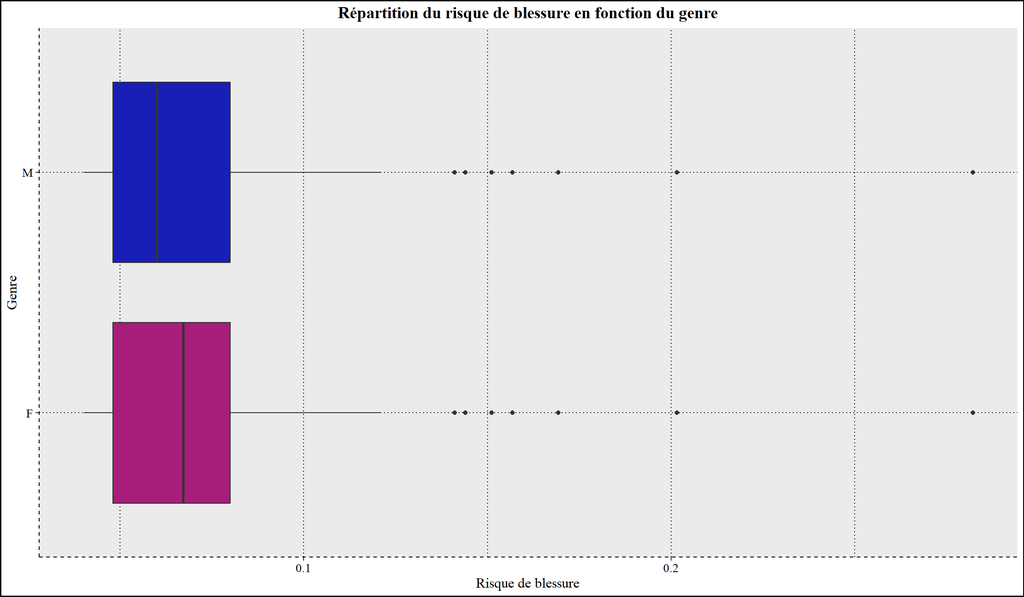

Graphique n°12 : Répartition du risque de blessure en fonction du genre

On n’observe aucune différence sur un simple graphique de relation entre le risque de blessure et le genre (*Graphique n°12*).

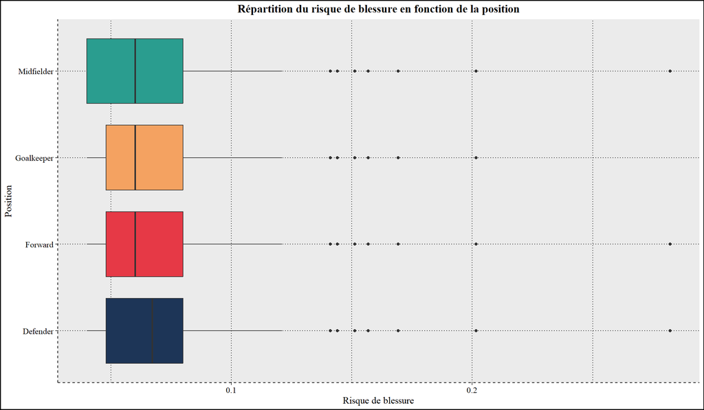

Graphique n°13 : Répartition du risque de blessure en fonction de la position

On observe encore une fois très peu de différences entre le risque de blessure et la position graphiquement (*Graphique n°13*).

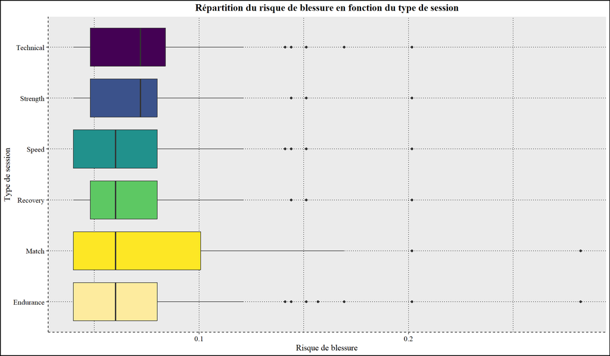

Graphique n°14 : Répartition du risque de blessure en fonction du type de session

On observe dans ce graphique de la relation entre le risque de blessure et le type de session qu’il semblerait y avoir un risque de blessure plus grand durant les matchs (*Graphique n°14*). Nous allons tester cette hypothèse durant notre ANOVA.

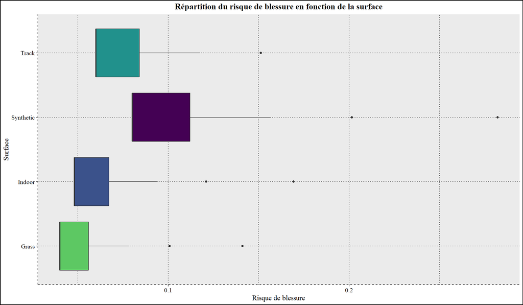

Graphique n°15 : Répartition du risque de blessure en fonction de la surface

On observe qu’il semblerait y avoir un risque de blessure plus élevé pour la surface **Synthetic** (*Graphique n°15*).

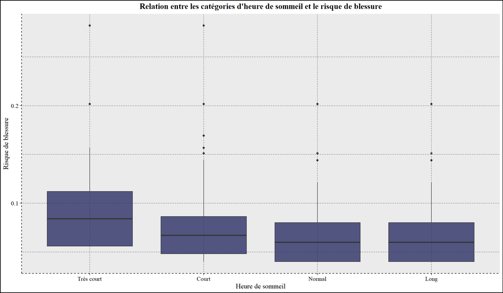

Graphique n°16 : Répartition des catégories d’heure de sommeil et le risque de blessure

Pour cette observation nous avons décidé de faire apparaître une nouvelle variable. Les catégories d’heure de sommeil. Entre 3h et 6h, un sommeil très court, entre 6h et 7h un sommeil court, entre 7h et 8.5h un sommeil normal et entre 8.5h et 11h un sommeil long (*Graphique n°16*).

On observe un risque de blessure plus élevé dans le groupe **sommeil très court** et un peu plus élevé dans le groupe **sommeil court** que les groupes **Normal** et **Long**. Nous allons tester cette hypothèse très intéressante durant notre ANOVA.

**Statistiques inférentielles et modélisation**

### Problématique n°1 : **Est-ce que le type de session influence la charge interne ?**

On commence par tester la **normalité** et l’**homogénéité** de la variable **srpe**.

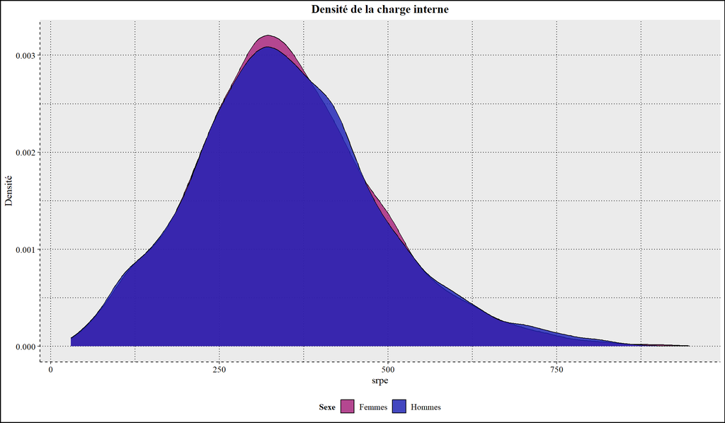

Graphique n°17 : Densité de la charge interne

Sur un graphique de densité, la distribution semble suivre une loi de Gauss (*Graphique n°17*).

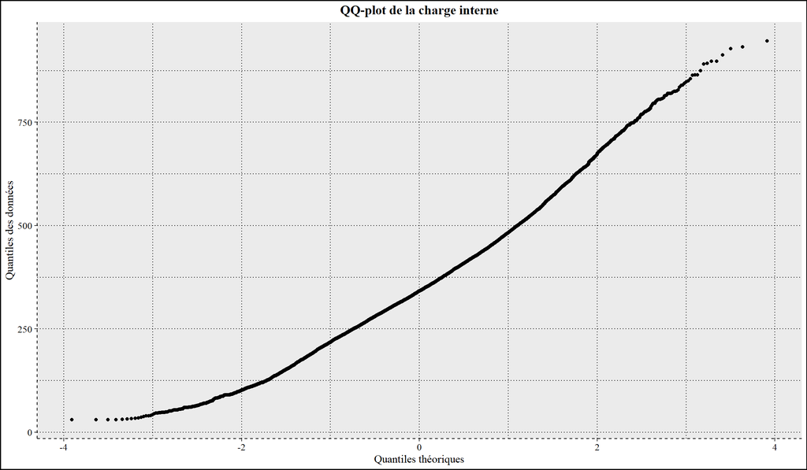

Graphique n°18 : QQ-plot de la charge interne

Un QQ-plot nous conforte aussi dans l’idée de la normalité mais on observe des queues assez asymétriques. (*Graphique n°18*)

```
Forte probabilité de normalité (W >= 0.90) : Les données semblent suivre une distribution normale.
 p-value < 0.05 : Rejet de l'hypothèse nulle. Les données ne suivent pas une distribution normale.
```

Tableau n°4 : Normalité de la variable spre

| Variable | W | p.values |
| --- | --- | --- |
| Charge interne | 28.934 | 0 |

La variable **srpe** ne suit pas une distribution normale. On a utilisé le test d’**Anderson-darling** car on a plus de 5 000 données (*Tableau n°4*).

```
On a une asymétrie de 0.5 et un aplatissement de 3.47
```

Après avoir fait un test d’asymétrie et d’aplatissement, les données sont légèrement étirées vers la droite et on a des queues légèrement plus lourdes que la normale.

Les données ne suivent pas une distribution normales et on a un large échantillon, on va donc utiliser le **test de Levene** pour déterminer l’homogénéité des variances entre le **srpe** et le type de session.

Tableau n°5 : Homogénéité des variances du srpe et du type de session

| Variable | W | p.values |
| --- | --- | --- |
| srpe - type de session | 85.615 | 0 |

On a une p.value < 0.05, les variances sont donc inégales (*Tableau n°5*). On va utiliser une ANOVA de Kruskal Wallis, le test non-paramétrique de l’ANOVA classique, car les données ne sont pas normales et hétérogènes avec un large échantillon.

Même si les graphiques ne semblent pas très asymétriques, on va utiliser le test de Kruskal Wallis. Car il n’y a pas de valeur aberrantes dans les rpe et je ne pense pas qu’il y en ai dans les durées non plus. Les durées les plus longues avec les rpe les plus hauts, donc les srpe les plus hauts, sont les matchs, donc c’est logique que cela puisse briser la normalité.

Tableau n°6 : ANOVA de la charge interne x le type de session

| Variable | Statisque_H | Degrés de liberté | p.values |
| --- | --- | --- | --- |
| Charge interne | 5051.499 | 5 | 0 |

On observe une statistique H très grande, donc une très grande différence avec une p.value < 0.05, donc une différence significative (*Tableau n°6*). On va donc faire un test Post-Hoc pour déterminer quels groupes diffèrent les uns des autres.

```
Après un test Post-Hoc, on a 15 paires significatives sur 15 paires
```

Tableau n°7 : Tests Post-Hoc de mon ANOVA de la charge interne x le type de session

| group_1 | group_2 | p.values | cliff_delta |
| --- | --- | --- | --- |
| Match | Endurance | 0 | 0.702 |
| Recovery | Endurance | 0 | -0.967 |
| Speed | Endurance | 0 | -0.237 |
| Strength | Endurance | 0 | -0.547 |
| Technical | Endurance | 0 | -0.471 |
| Recovery | Match | 0 | -0.999 |
| Speed | Match | 0 | -0.828 |
| Strength | Match | 0 | -0.929 |
| Technical | Match | 0 | -0.900 |
| Speed | Recovery | 0 | 0.946 |
| Strength | Recovery | 0 | 0.838 |
| Technical | Recovery | 0 | 0.864 |
| Strength | Speed | 0 | -0.366 |
| Technical | Speed | 0 | -0.279 |
| Technical | Strength | 0 | 0.086 |

Toutes les situations diffèrent les unes des autres (*Tableau n°7*). On valide notre hypothèse qui est que le type de session influence la charge interne.

En revanche on observe une différence très grande entre le type de session Match et tous les autres types de sessions. On peut ajouter qu’au vu de la direction de la différence, le Match a tendance à être très au-dessus des autres situations en terme de charge interne.

On valide donc nos deux hypothèses de départ. La charge interne dépend du type de session et de plus le Match est au-dessus en terme de charge interne par rapport aux autres situations.

### Problématique n°2 : **Est-ce que les types de blessures dépendent de la position ?**

On peut effectuer directement notre test du Chi² entre les types de blessures et la position car nos deux variables sont en effet catégorielles et supérieures à 5.

Tableau n°8 : Test du Chi² de la variable type de blessure x position

| Variable | Statistique | p.value |
| --- | --- | --- |
| Résultats | 21.553 | 0.252 |

On a la p.value > 0.05, il n’existe donc pas d’association significative entre le type de blessure et la position (*Tableau n°8*).

Lorsque l’on regarde le graphique n°11, en effet, mis à part pour le groupe défenseur, on n’observe pas de différence flagrante. On a tout de même l’impression que le groupe défenseur diffère largement des autres. Il faudrait le tester séparément pour déterminer s’il existe une différence significative de ce groupe avec les autres.

Il y a 7 groupes, la différence du groupe défenseur peut-être noyée à cause des autres groupes, mais je ne sais pas si c’est un biais de le tester séparément avec les autres groupes afin de déterminer si ce groupe spécifiquement diffère des autres.

On va dire que c’est une ouverture faisable, étudier spécifiquement le groupe des défenseurs.

### Problématique n°3 : **De quoi dépend le risque de blessure ?**

Notre troisième problématique est plus complexe que les deux premières. On va commencer par faire des tests de normalités et d’homogénéité des variances.

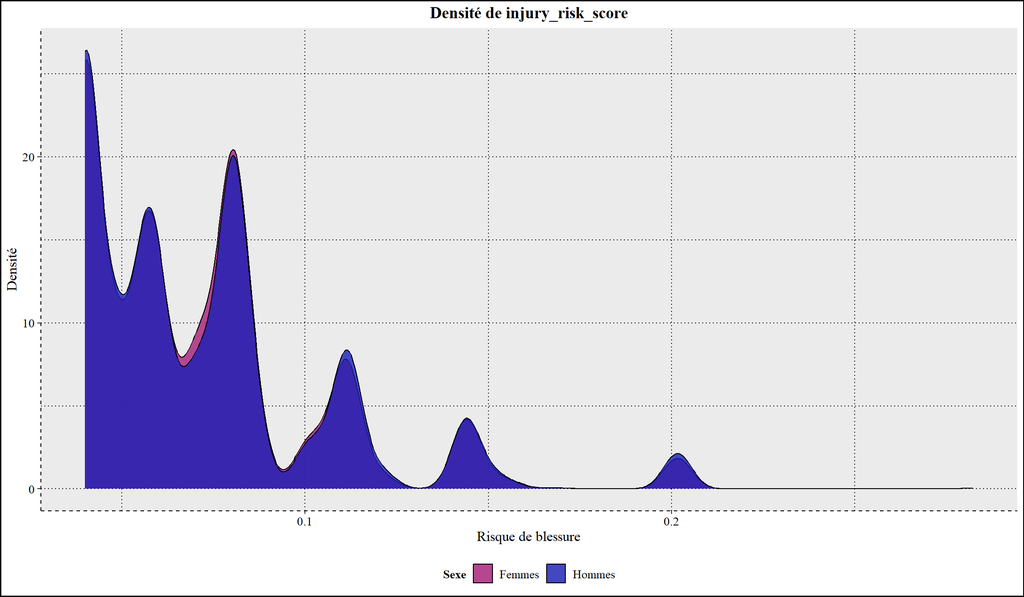

Graphique n°19 : Densité du risque de blessure

À l’aide d’un graphique de densité, on peut observer que la variable du risque de blessure ne parait pas du tout normale.

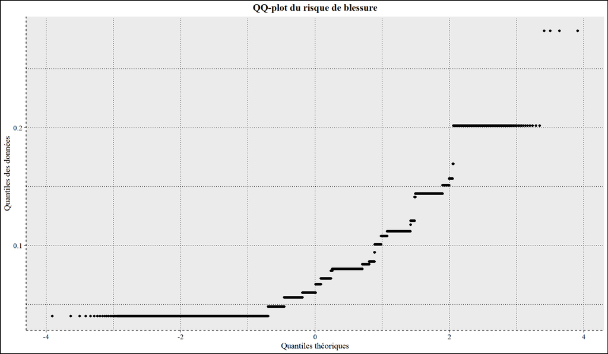

Graphique n°20 : QQ-plot du risque de blessure

On peut faire la même conclusion avec un QQ-Plot.

Tableau n°9 : Normalité de la variable injury_risk_score

| Variable | W | p.values |
| --- | --- | --- |
| Risque de blessure | 453.626 | 0 |
| Risque de blessure Homme | 239.281 | 0 |
| Risque de blessure Femme | 214.327 | 0 |

La variable du risque de blessure ne suit pas une loi de normalité. La variable du risque de blessure par genre ne suit pas non plus une loi de normalité.

Tableau n°10 : Homogénéité des variances du risque de blessure

| Variable | W | p.values |
| --- | --- | --- |
| risque de blessure - genre | 1.982 | 0.159 |
| risque de blessure - position | 0.433 | 0.730 |
| risque de blessure - type de session | 9.406 | 0.000 |
| risque de blessure - surface | 163.031 | 0.000 |
| risque de blessure - catégorie de sommeil | 67.181 | 0.000 |

On observe un homogénéité des variances entre le risque de blessure, le genre et la position mais pas avec les autres variables. On peut faire un t-test sur échantillon indépendant classique entre le risque de blessure et le genre.

```
    Two Sample t-test

data:  injury_risk_score by gender
t = -0.64435, df = 10845, p-value = 0.5194
alternative hypothesis: true difference in means between group F and group M is not equal to 0
95 percent confidence interval:
 -0.0016848051  0.0008511826
sample estimates:
mean in group F mean in group M
     0.07204998      0.07246679
```

Après un t-test classique sur échantillon indépendant. On a une p.value > 0.05, il n’y a donc pas de différence significative entre le risque de blessure des hommes et des femmes. Et on a un t très proche de 0, donc une différence très faible, significative ou non.

Tableau n°11 : ANOVA entre risque de blessure et mes variables catégorielles

| Variable | Statisque_H | p.values |
| --- | --- | --- |
| Risque de blessure - Genre | 0.001 | 0.971 |
| Risque de blessure - Position | 2.922 | 0.404 |
| Risque de blessure - Type de session | 57.457 | 0.000 |
| Risque de blessure - Surface | 5986.839 | 0.000 |
| Risque de blessure - Catégorie de sommeil | 818.850 | 0.000 |

On a une p.value > 0.05 pour l’interaction entre le risque de blessure et le genre et l’interaction du risque de blessure et la position, donc pas de différence significative. On observe en revanche une différence significative au sein des groupes de type de session de surface et des catégories de sommeil. Ce qui est en accord avec nos premiers graphiques. On ne va pas faire de test Post-Hoc ici, car ce n’est pas ce qui nous intéresse pour notre problématique.

Pour aller plus loin, on peut faire un modèle linéaire généralisé afin d’étudier les interactions de nos variables catégorielles avec le risque de blessure.

```
Call:
glm(formula = injury_risk_score ~ gender + position + session_type +
    surface + sleep_category, family = quasibinomial(), data = datas)

Coefficients:
                        Estimate Std. Error  t value Pr(>|t|)
(Intercept)           -2.6553102  0.0116607 -227.715   <2e-16 ***
genderM               -0.0027202  0.0063421   -0.429    0.668
positionForward        0.0001608  0.0085296    0.019    0.985
positionGoalkeeper     0.0069679  0.0114060    0.611    0.541
positionMidfielder    -0.0023708  0.0077510   -0.306    0.760
session_typeMatch      0.1523670  0.0119058   12.798   <2e-16 ***
session_typeRecovery  -0.0116546  0.0124126   -0.939    0.348
session_typeSpeed     -0.0077804  0.0095672   -0.813    0.416
session_typeStrength  -0.0059981  0.0103496   -0.580    0.562
session_typeTechnical -0.0014594  0.0096145   -0.152    0.879
surfaceIndoor          0.2151011  0.0107449   20.019   <2e-16 ***
surfaceSynthetic       0.7642774  0.0075470  101.269   <2e-16 ***
surfaceTrack           0.4285943  0.0101920   42.052   <2e-16 ***
sleep_categoryCourt   -0.2076655  0.0093746  -22.152   <2e-16 ***
sleep_categoryNormal  -0.3620279  0.0089801  -40.314   <2e-16 ***
sleep_categoryLong    -0.3813814  0.0125258  -30.448   <2e-16 ***
---
Signif. codes:  0 '***' 0.001 '**' 0.01 '*' 0.05 '.' 0.1 ' ' 1

(Dispersion parameter for quasibinomial family taken to be 0.007210867)

    Null deviance: 162.446  on 10846  degrees of freedom
Residual deviance:  70.714  on 10831  degrees of freedom
AIC: NA

Number of Fisher Scoring iterations: 6
```

On retrouve nos résultats précédents, pas de différence homme - femme.

On n’observe pas de différence entre la position défense et les autres positions.

On observe une différence entre la situation d’endurance et de match de plus de 15 %. Cela voudrait dire que l’on a 15 % plus de chance de se blesser en match par rapport à la situation en endurance.

Le modèle est très intéressant ensuite.

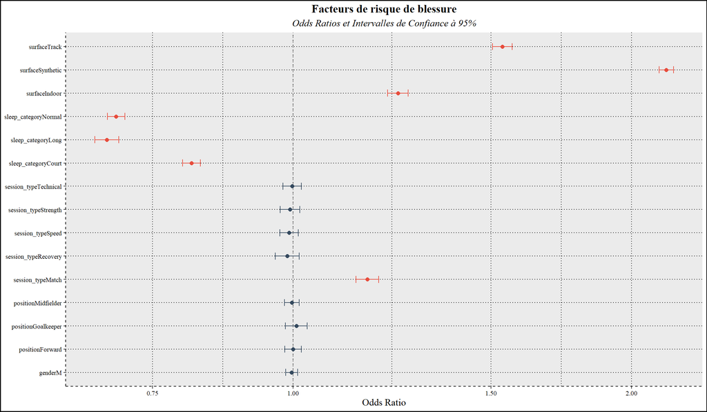

Graphique n°21 : Forest plot

Ce forest plot résume particulièrement bien tout ce qu’on vient de dire précédement.

Pour aller encore un peu plus loin, on peut modéliser l’interaction des variables catégorielles entre elles par rapport au risque de blessure. Par exemple gender * surface

```
$emmeans
 gender surface     prob       SE  df asymp.LCL asymp.UCL
 F      Grass     0.0536 0.000353 Inf    0.0529    0.0543
 M      Grass     0.0535 0.000349 Inf    0.0528    0.0542
 F      Indoor    0.0656 0.000611 Inf    0.0644    0.0668
 M      Indoor    0.0655 0.000603 Inf    0.0643    0.0667
 F      Synthetic 0.1084 0.000637 Inf    0.1072    0.1097
 M      Synthetic 0.1082 0.000622 Inf    0.1070    0.1094
 F      Track     0.0800 0.000712 Inf    0.0786    0.0814
 M      Track     0.0798 0.000708 Inf    0.0784    0.0812

Results are averaged over the levels of: position, session_type, sleep_category
Confidence level used: 0.95
Intervals are back-transformed from the logit scale

$contrasts
 contrast                  odds.ratio      SE  df null  z.ratio p.value
 F Grass / M Grass              1.003 0.00636 Inf    1    0.429  0.9999
 F Grass / F Indoor             0.806 0.00867 Inf    1  -20.019  <.0001
 F Grass / M Indoor             0.809 0.01010 Inf    1  -17.084  <.0001
 F Grass / F Synthetic          0.466 0.00351 Inf    1 -101.269  <.0001
 F Grass / M Synthetic          0.467 0.00458 Inf    1  -77.603  <.0001
 F Grass / F Track              0.651 0.00664 Inf    1  -42.052  <.0001
 F Grass / M Track              0.653 0.00784 Inf    1  -35.464  <.0001
 M Grass / F Indoor             0.804 0.01010 Inf    1  -17.395  <.0001
 M Grass / M Indoor             0.806 0.00867 Inf    1  -20.019  <.0001
 M Grass / F Synthetic          0.464 0.00460 Inf    1  -77.457  <.0001
 M Grass / M Synthetic          0.466 0.00351 Inf    1 -101.269  <.0001
 M Grass / F Track              0.650 0.00780 Inf    1  -35.943  <.0001
 M Grass / M Track              0.651 0.00664 Inf    1  -42.052  <.0001
 F Indoor / M Indoor            1.003 0.00636 Inf    1    0.429  0.9999
 F Indoor / F Synthetic         0.577 0.00595 Inf    1  -53.297  <.0001
 F Indoor / M Synthetic         0.579 0.00701 Inf    1  -45.124  <.0001
 F Indoor / F Track             0.808 0.01010 Inf    1  -17.096  <.0001
 F Indoor / M Track             0.810 0.01140 Inf    1  -15.001  <.0001
 M Indoor / F Synthetic         0.576 0.00696 Inf    1  -45.653  <.0001
 M Indoor / M Synthetic         0.577 0.00595 Inf    1  -53.297  <.0001
 M Indoor / F Track             0.806 0.01120 Inf    1  -15.486  <.0001
 M Indoor / M Track             0.808 0.01010 Inf    1  -17.096  <.0001
 F Synthetic / M Synthetic      1.003 0.00636 Inf    1    0.429  0.9999
 F Synthetic / F Track          1.399 0.01390 Inf    1   33.892  <.0001
 F Synthetic / M Track          1.403 0.01660 Inf    1   28.672  <.0001
 M Synthetic / F Track          1.395 0.01630 Inf    1   28.411  <.0001
 M Synthetic / M Track          1.399 0.01390 Inf    1   33.892  <.0001
 F Track / M Track              1.003 0.00636 Inf    1    0.429  0.9999

Results are averaged over the levels of: position, session_type, sleep_category
P value adjustment: tukey method for comparing a family of 8 estimates
Tests are performed on the log odds ratio scale
```

Ce genre de modèle permet de plonger profondément dans les interactions des groupes les uns envers les autres.

On observe pas grand chose de plus de ce qu’on a déjà conclu plus haut.

On pourrait faire ça pour toutes nos variables, mais on a déjà validé notre problématique.

Ensuite,

Avant de faire mes tests de corrélations, je test la normalité de mes variables.

| Variable | W | p.values |
| --- | --- | --- |
| srpe | 28.934 | 0 |
| Distance en km | 62.517 | 0 |
| distance à haute vitesse | 147.325 | 0 |
| Accélérations | 33.057 | 0 |
| Décélérations | 31.359 | 0 |

Aucune de nos variables ne suivent une distribution normale, on va donc faire des corrélations non linéaires de Spearman.

Tableau n°13 : Corrélations entre le risque de blessure et mes variables quantitatives continues d’intérêt

| p.values | Coefficients | sens | Force de correlation |
| --- | --- | --- | --- |
| 0.397 | 0.008 | Positive | Très faible / Nulle |
| 0.000 | 0.086 | Positive | Très faible / Nulle |
| 0.000 | 0.066 | Positive | Très faible / Nulle |
| 0.000 | 0.058 | Positive | Très faible / Nulle |
| 0.000 | 0.040 | Positive | Très faible / Nulle |

Après avoir fait des tests de corrélations entre le risque de blessure et nos variables, on ne remarque aucune corrélation.

À ce niveau, cela ne sert à rien de faire un modèle de régression multiple, car on observe très peu de corrélation entre nos variables et le risque de blessure. Et même si l’on étudie l’interaction de nos variables entre elles par rapport au risque de blessure, je pense pas que cela donne quelque chose de significatif.

**Pour résumer…**

### Problématique n°1

On valide notre hypothèse, la charge interne dépend du type de session. Et de plus, on a déterminé que la situation de Match augmente la charge interne en rapport aux autres situations.

**Discussion** : Les résultats montrent clairement que le type de session influence la charge interne. Le descriptif indiquait déjà des différences marquées entre les séances, avec un niveau particulièrement élevé lors des Matchs, ce que les tests statistiques ont confirmé. L’ANOVA met en évidence des différences significatives entre tous les types de sessions, et les tests Post-Hoc montrent que le Match se distingue nettement avec une charge interne beaucoup plus élevée. Les tailles d’effet confirment l’ampleur de ces écarts.

**Limites** : Plusieurs limites doivent être considérées,

Le type de session n’explique qu’une partie de la charge interne, d’autres facteurs non étudiés (fatigue, durée, contenu détaillé, profil des joueurs) pouvant également influencer les résultats.

Les nombreuses variables disponibles n’ont pas été exploitées, ce qui limite une vision plus globale des relations possibles.

La charge interne repose en partie sur des mesures subjectives, pouvant introduire de la variabilité.

Les catégories de sessions peuvent être déséquilibrées en nombre, ce qui affecte la robustesse des comparaisons.

Enfin, l’analyse décrit une influence mais n’explique pas les mécanismes précis qui conduisent à ces différences.

### Problématique n°2

On invalide notre hypothèse. Le type de blessure ne dépend pas de la position. En revanche, il serait possible de tester le groupe des défenseurs séparément, car on observe une différence graphiquement avec les autres groupes.

**Discussion** : L’objectif était de déterminer si le type de blessure dépend de la position. Le graphique suggérait une différence potentielle chez les défenseurs, notamment avec un nombre plus élevé de commotions, alors qu’aucune tendance notable n’apparaissait pour les autres postes.

Cependant, le test du Chi² n’a pas montré d’association significative entre la position et le type de blessure (p > 0.05). Ainsi, l’hypothèse d’un lien global entre ces deux variables doit être rejetée.

Malgré tout, le signal observé chez les défenseurs reste intéressant et pourrait être exploré plus spécifiquement. Il est possible que la présence de nombreux groupes dilue cet effet potentiel, rendant difficile sa détection dans un test global. Une analyse ciblée défenseurs vs autres positions pourrait être envisagée, avec prudence.

**Limites** : Les effectifs peuvent être déséquilibrés entre positions, limitant la puissance du test du Chi².

Le grand nombre de catégories fragmente les données et peut masquer un effet présent dans un seul groupe.

Le graphique suggère une tendance visuelle, mais celle-ci repose sur des effectifs faibles et n’est pas statistiquement confirmée.

De nombreux facteurs non étudiés (intensité de jeu, exposition aux duels, antécédents…) peuvent influencer les blessures.

Tester un groupe isolé (ex : défenseurs) comporte un risque d’analyses post-hoc non prévues initialement.

### Problématique n°3

On valide notre hypothèse. Le risque de blessure dépend d’au moins une variable. Principalement du type de session, de la surface et des catégories de sommeil.

**Discussion** : L’objectif était d’identifier de quelles variables dépend le risque de blessure. Les analyses descriptives et statistiques montrent qu’il n’existe aucune différence significative du risque de blessure selon le genre ou la position, ce qui suggère que ces facteurs ne jouent pas un rôle majeur dans cet échantillon.

En revanche, trois variables ressortent clairement : le type de session, la surface, et la catégorie de sommeil. Les matchs présentent un risque plus élevé que les autres séances ; les surfaces synthétiques augmentent fortement le risque par rapport à l’herbe ; et le risque diminue graduellement lorsque la durée de sommeil augmente.

Globalement, la problématique est validée : le risque de blessure dépend bien de certaines variables, essentiellement liées au contexte de la séance, à la surface et au sommeil.

**Résultats** :

Le risque de blessure est un phénomène multifactoriel difficile à résumer avec un seul score.

Les tests univariés ne permettent pas de capturer des interactions complexes entre variables.

Certaines analyses (GLM, interactions) peuvent manquer de puissance à cause du nombre de groupes ou du déséquilibre des effectifs.

Les variables quantitatives utilisées ne reflètent que la charge aiguë, et non la charge chronique, souvent plus pertinente pour le risque de blessure.

Les pourcentages issus du GLM doivent être interprétés avec prudence.

Les données répétées provenant des mêmes individus ne sont pas modélisées, ce qui peut introduire un biais.